# IO Streams

- Writing a file
- Reading a file
- Serialization

## IO Streams

Used for accessing data outside program, that is from an external source or destination.

That means data can flow in or flow out.

Flow in (>>), that means, getting information from keyboard to program [in to program] Flow out (<<), that means, getting information from program [out of program] to the monitor

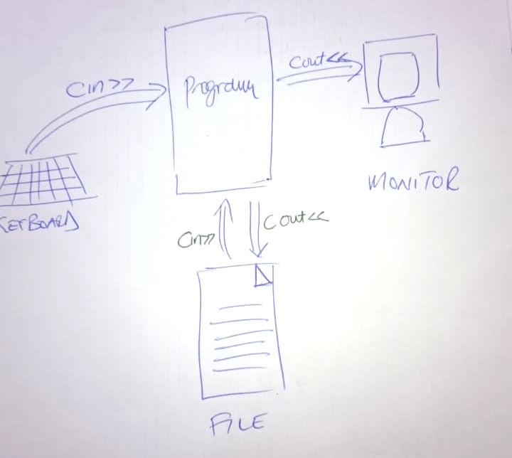

For accessing the above source/destinatons, we use the mechanism of (Input/Output) Stream or iostream

And there are built-in classes in C++ for accessing Input/Output Stream

The class is **ios**, that is input and output stream, which is divided into follow classes:

- istream (for input stream) : e.g. `cin>>name` [EXTRACTION] *from keyboard*
- ostream (for output stream): e.g. `cout<<x` [INSERTION] *into monitor*

And for files it furher divided into:

- ifstream (for input stream)
- ofstream (for output stream)

### How to handle files in C++

#### Writing data to a file

Must use the preprocessor direction or `<fstream> header file`

```
#include <fstream>
```

By default, if the file does not exist, it wil create a file

If it already exist, it will create a new file with the same name. That is the contents will be truncated/wiped, and it will be ready for new input.

```
ofstream outfile(myFile.txt) or (by default truncate is taken so normally left out--> outfile(myFile.txt, ios:trunc))
```

if you want to keep contents, and append to it, then use:

```
ofstream outfile(myFile.txt, ios: app)
```

And outfile is associated with file to be written:

```
outfile<<"Hello"<<endl;
outfile<<25<<endl;
outfile<<"Conrad"<<endl;
```

#### Reading data to a file

We change from ofstream (output) to ifstream(Input)

When readinfg from file, file must exist. So must check if file is open or not

Now the direction is from file to program

```
infile>>str;
infile>>i;
```

And then once we have in the program, two variable, we want to output to screen:

```
c<<str<<e;
c<<i<<e;
```

#### Serialisation

Idea about serialisation, is to package information into object, and write or read the object.

Where you want to store individual values as objects.

So what do we have. We have indvidual pieces of information

```
s1.name="John";
s1.roll="26";
s1.branch="CS";
```

And normally we would just write it out as follows:

```
ofstream ofs("Student.txt", ios:: trunc);
ofs<<s1.name<<e;
ofs<<s1.roll<<e;
ofs<<s1.branch<<e;
```

But we want to write: `ofs<<s1`, so we want to **overload the insertion operator**

(or we could have just written a function Serialise(), and just call ofs<<s1.Serialise())

```python
#include <iostream>
#include <fstream>
#define c cout
#define e endl
#define INSERTION_OPERATOR operator<<
#define EXTRACTION_OPERATOR operator>>
using namespace std;
```

#### Writing data to a file

```python
ofstream outfile("myFile.txt")
```

```python
outfile<<"Hello"<<endl;
```

```python
outfile<<25<<endl;
```

```python
outfile<<"Conrad"<<endl;
```

```python
outfile.close();
```

#### Reading data to a file

```python
string str;
int i;
ifstream infile("myFile.txt")
```

```python
if(!infile){
    c<<"File cannot be opened"<<e;
}
```

```python
infile>>str;
infile>>i;
```

```python
c<<str<<e;
c<<i<<e;
```

```
Hello
25
```

```python
infile.close();
```

```python
class Student{
public:
    string name;
    int roll;
    string branch;

    friend ofstream & INSERTION_OPERATOR(ofstream &ofs, Student &s1);
    friend ifstream & EXTRACTION_OPERATOR(ifstream &ifs, Student &s2);
    friend ostream & INSERTION_OPERATOR(ostream &o, Student &s3);

}
```

```python
ofstream & INSERTION_OPERATOR(ofstream &ofs, Student &s1){
    ofs<<s1.name<<endl;
    ofs<<s1.roll<<endl;
    ofs<<s1.branch<<endl;
    return ofs;
}
```

```python
ifstream & EXTRACTION_OPERATOR(ifstream &ifs, Student &s2){
    ifs>>s2.name;
    ifs>>s2.roll;
    ifs>>s2.branch;
    return ifs;
}
```

```python
ostream & INSERTION_OPERATOR(ostream &o, Student &s3){
    o<<s3.name<<" % "<<s3.roll<<" - "<<s3.branch<<endl;
    return o;
}
```

#### Serialisation of a file (to disk)

```python
Student s1;
s1.name="Chesney";
s1.roll=48;
s1.branch="Conrad";
```

```python
ofstream ofs("Student.txt", ios:: trunc);
```

```python
// ofs<<s1.name<<e;
// ofs<<s1.roll<<e;
// ofs<<s1.branch<<e;
```

```python
ofs<<s1;
ofs.close();
```

#### Serialisation from a file (from disk)

```python
ifstream ifs("Student.txt");
```

```python
Student s2;
```

```python
ifs>>s2;
ifs.close();
```

```python
c<<s2<<e;
```

```
Chesney % 48 - Conrad
```